# Lésions de la main par pétards 2015-2016

JcB - RESURAL

10/01/2016

# Pétards 2015-2016

Les lésions graves de la mains provoquées par l’explosion de pétards à l’occasion du réveillon sont un motif fréquent de consultation sans les services spécialisés. Depuis 2015 en Alsace, les trois services SOS Mains de la région (CCOM, Diaconat-Strasbourg, Diaconat-Roosevelt) remontent des RPU. Il a paru intéressant de colliger les cas à partir des RPU comporant le code CIM10 W39 comme diagnostic principal (DP). La consigne d’utiliser prioritairement de code avait été préalablement donnée à l’ensemble des structures d’urgence.

## Fréquence

La période d’observation s’étend du 25 décembre 2015 au 6 janvier 2016. On observe **12** cas de lésions par pétards. La plus pécoce date du 28 décembre, les plus tardives du 2 janvier avec un pic le premier janvier, essentiellement entre minuit et 6 heures du matin.

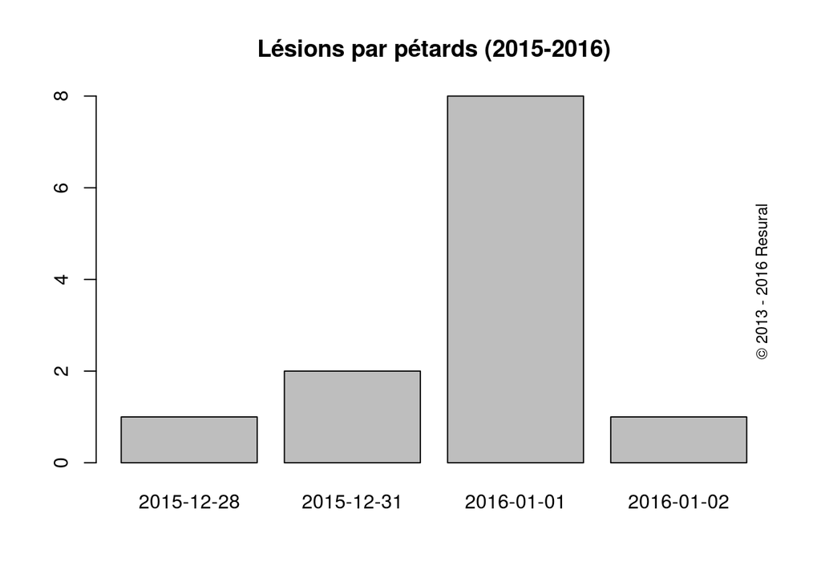

## Age

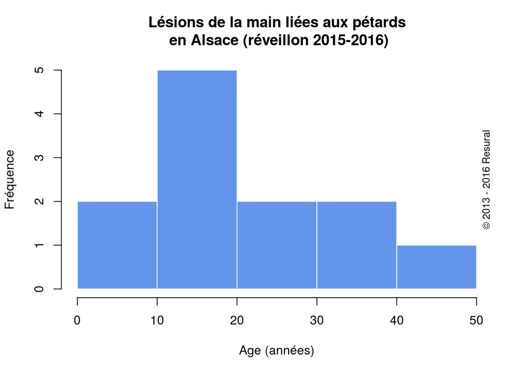

## Sexe

Il existe une nette prédominance masculine: 11 hommes pour une femme.

```
 F  M
 1 11
```

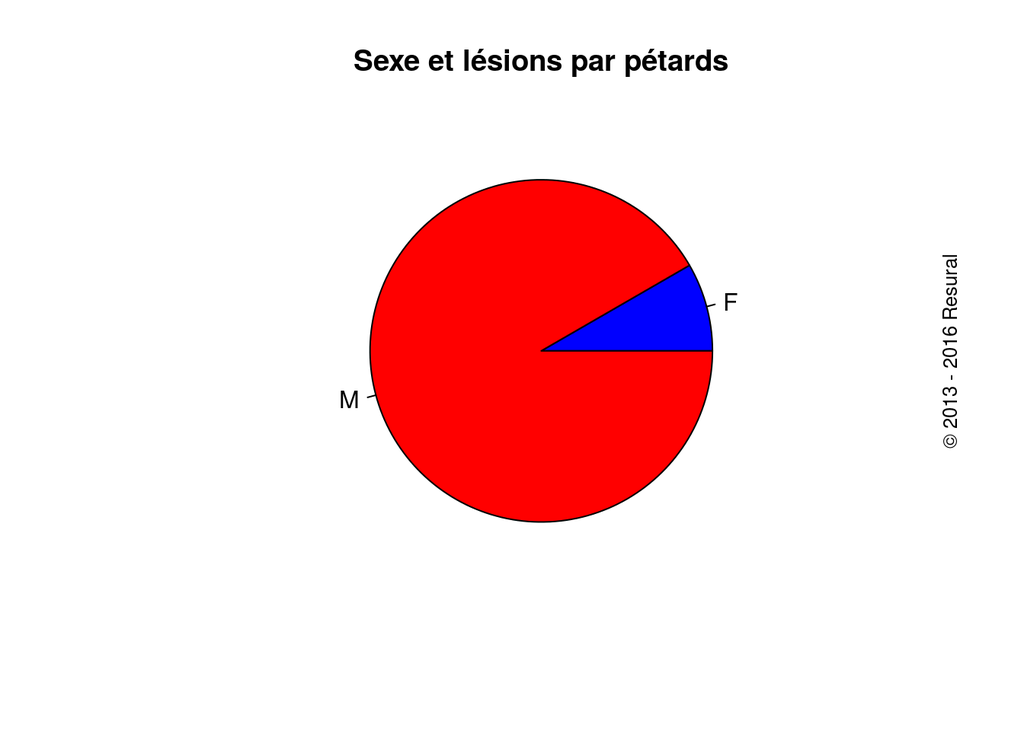

## Origine

La quasi totalité des patients sont originaires du bas-Rhin.

```
             Nombre
ACHENHEIM         1
BRUMATH           1
FEGERSHEIM        1
GUEBWILLER        1
HAGUENAU          1
REICHSHOFFEN      1
SAVERNE           3
SCHILTIGHEIM      1
STRASBOURG        1
WISSEMBOURG       1
```

## Prise en charge

La majorité des patients (10 sur 12) ont été pris en charge par les services SOS Mains de Strasbourg. Deux patients ont été pris en charge par un service d’urgence polyvalent.

```
Dts Geb Wis Ccm
  5   1   1   5
```